# Actividad1 - Medias Móviles

Camila Turner Escalante & Ramona Nájera Fuentes

17/06/2022

```r
knitr::opts_chunk$set(echo = TRUE)

# Librerías
library(readxl)
library(forecast)
library(smooth)
library(dplyr)
```

Leer los datos

```r
datos <- read_excel("./demandas_semanales.xlsx")
attach(datos)
```

Convertir a objeto tipo serie de tiempo

```r
datos_ts = ts(datos$Demanda, start = c(1,1), frequency = 7)
datos_ts
```

```
## Time Series:
## Start = c(1, 1)
## End = c(5, 2)
## Frequency = 7
##  [1]  800 1400 1000 1500 1500 1300 1800 1700 1300 1700 1700 1500 2300 2300 2000
## [16] 1700 1800 2200 1900 2400 2400 2600 2000 2500 2600 2200 2200 2500 2400 2100
```

## 0.1 Utiliza promedios simples basados en 3 y 9 semanas para predecir la semana de las cinco semanas siguientes.

**PROMEDIOS SIMPLES BASADOS EN 3 SEMANAS (ma(order=3))**

```r
pronosMA3 <- ma(datos_ts, order=3)
summary(pronosMA3)
```

```
##    Min. 1st Qu.  Median    Mean 3rd Qu.    Max.    NA's
##    1067    1592    1983    1932    2333    2467       2
```

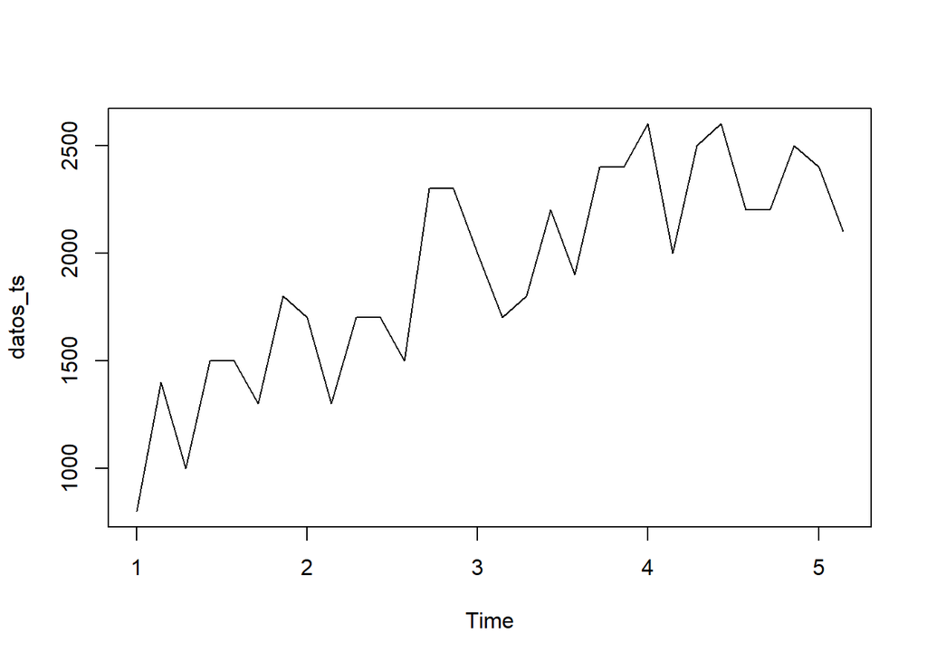

```r
plot(datos_ts)
```

```r
#lines(pronosMA3, col="red")

modeloMA3 <- arima(datos_ts,order=c(0,0,3))
summary(modeloMA3)
```

```
##
## Call:
## arima(x = datos_ts, order = c(0, 0, 3))
##
## Coefficients:
##          ma1     ma2     ma3  intercept
##       0.4492  0.7109  0.8073  1868.8780
## s.e.  0.1342  0.2549  0.2531   158.7821
##
## sigma^2 estimated as 93824:  log likelihood = -216.98,  aic = 443.97
##
## Training set error measures:
##                    ME     RMSE      MAE       MPE     MAPE      MASE
## Training set 25.64503 306.3074 234.8275 -2.626631 14.37323 0.8011761
##                     ACF1
## Training set -0.05686866
```

```r
datos_ts.add <- decompose(datos_ts,type="additive")
datos_ts.mult <- decompose(datos_ts,type="multiplicative")

auto.arima(datos_ts,trace=T) #sacar mejor modelo
```

```
##
##  ARIMA(2,1,2)(1,0,1)[7] with drift         : 430.2688
##  ARIMA(0,1,0)           with drift         : 427.7916
##  ARIMA(1,1,0)(1,0,0)[7] with drift         : 424.2642
##  ARIMA(0,1,1)(0,0,1)[7] with drift         : Inf
##  ARIMA(0,1,0)                              : 425.93
##  ARIMA(1,1,0)           with drift         : 424.6211
##  ARIMA(1,1,0)(1,0,1)[7] with drift         : 426.9452
##  ARIMA(1,1,0)(0,0,1)[7] with drift         : 424.9874
##  ARIMA(0,1,0)(1,0,0)[7] with drift         : 429.4762
##  ARIMA(2,1,0)(1,0,0)[7] with drift         : 421.0746
##  ARIMA(2,1,0)           with drift         : 421.2284
##  ARIMA(2,1,0)(1,0,1)[7] with drift         : 424.2519
##  ARIMA(2,1,0)(0,0,1)[7] with drift         : 421.2281
##  ARIMA(3,1,0)(1,0,0)[7] with drift         : 424.2552
##  ARIMA(2,1,1)(1,0,0)[7] with drift         : Inf
##  ARIMA(1,1,1)(1,0,0)[7] with drift         : Inf
##  ARIMA(3,1,1)(1,0,0)[7] with drift         : Inf
##  ARIMA(2,1,0)(1,0,0)[7]                    : 419.8049
##  ARIMA(2,1,0)                              : 421.1777
##  ARIMA(2,1,0)(1,0,1)[7]                    : 422.7469
##  ARIMA(2,1,0)(0,0,1)[7]                    : 420.3947
##  ARIMA(1,1,0)(1,0,0)[7]                    : 422.2003
##  ARIMA(3,1,0)(1,0,0)[7]                    : 422.7229
##  ARIMA(2,1,1)(1,0,0)[7]                    : 422.707
##  ARIMA(1,1,1)(1,0,0)[7]                    : 420.8006
##  ARIMA(3,1,1)(1,0,0)[7]                    : 425.8954
##
##  Best model: ARIMA(2,1,0)(1,0,0)[7]
```

```
## Series: datos_ts
## ARIMA(2,1,0)(1,0,0)[7]
##
## Coefficients:
##           ar1      ar2    sar1
##       -0.7468  -0.4335  0.4093
## s.e.   0.1896   0.1814  0.1801
##
## sigma^2 = 84723:  log likelihood = -205.07
## AIC=418.14   AICc=419.8   BIC=423.61
```

```r
#ARIMA(2,1,0)(1,0,0)[7] --> mejor modelo según R

modeloMA3_2 <- arima(datos_ts, order=c(2,1,0),seasonal=list(order=c(1,0,0)))
modeloMA3_2
```

```
##
## Call:
## arima(x = datos_ts, order = c(2, 1, 0), seasonal = list(order = c(1, 0, 0)))
##
## Coefficients:
##           ar1      ar2    sar1
##       -0.7468  -0.4335  0.4093
## s.e.   0.1896   0.1814  0.1801
##
## sigma^2 estimated as 75959:  log likelihood = -205.07,  aic = 418.14
```

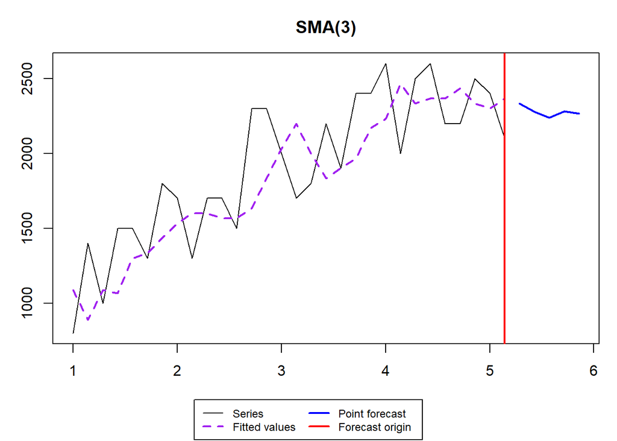

```r
# -------- PRONÓSTICOS ---------

#datos_forecast_MA3 <- forecast(modeloMA3_2, h=5) #aquí debes poner el mejor modelo
#datos_forecast_MA3
#plot(datos_forecast_MA3)


datos_fc_MA3 <- sma(datos_ts,order=3,h=5,silent=FALSE)
```

```r
fc1 <- forecast(datos_fc_MA3)
print(fc1)
```

```
## Time Series:
## Start = c(5, 3)
## End = c(6, 5)
## Frequency = 7
##          Point forecast Lower bound (2.5%) Upper bound (97.5%)
## 5.285714       2333.333           1683.090            2983.577
## 5.428571       2277.778           1592.361            2963.194
## 5.571429       2237.037           1493.185            2980.889
## 5.714286       2282.716           1444.985            3120.447
## 5.857143       2265.844           1377.014            3154.673
## 6.000000       2261.866           1315.899            3207.832
## 6.142857       2270.142           1266.482            3273.801
## 6.285714       2265.950           1212.897            3319.003
## 6.428571       2265.986           1163.637            3368.335
## 6.571429       2267.359           1117.620            3417.099
```

**PROMEDIOS SIMPLES BASADOS EN 9 SEMANAS (ma(order=9))**

```r
pronosMA9 <- ma(datos_ts, order=9)
summary(pronosMA9)
```

```
##    Min. 1st Qu.  Median    Mean 3rd Qu.    Max.    NA's
##    1367    1750    1972    1958    2242    2378       8
```

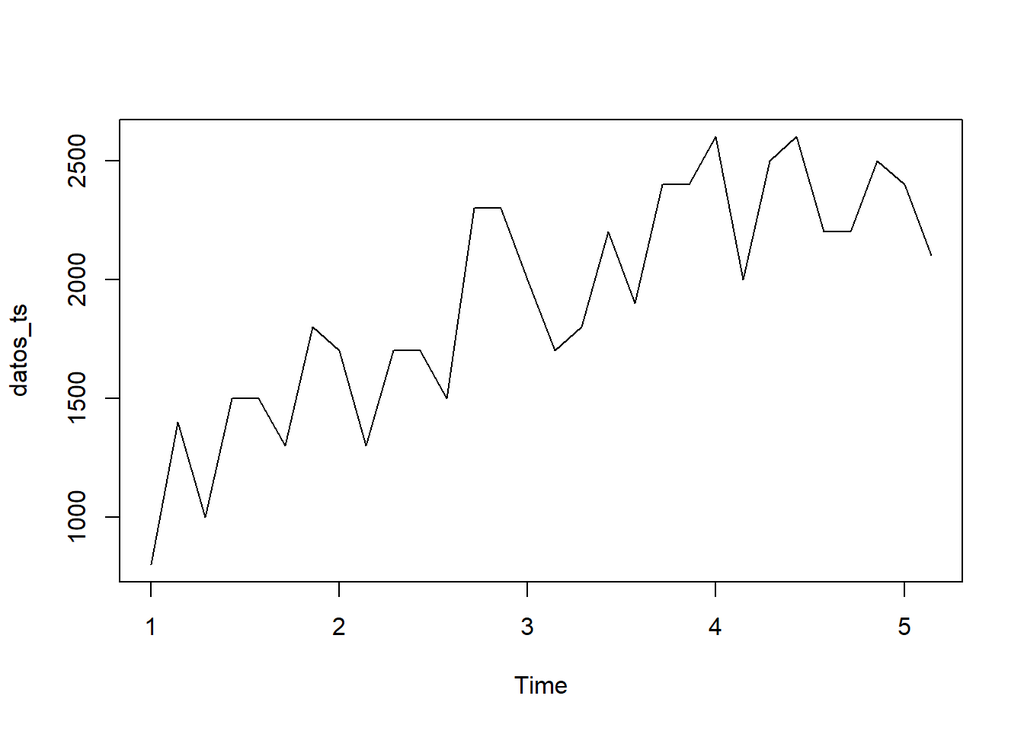

```r
plot(datos_ts)
```

```r
#lines(pronosMA9, col="red")

modeloMA9 <- arima(datos_ts,order=c(0,0,9))
summary(modeloMA9)
```

```
##
## Call:
## arima(x = datos_ts, order = c(0, 0, 9))
##
## Coefficients:
##          ma1     ma2     ma3     ma4     ma5     ma6     ma7     ma8     ma9
##       0.3182  0.3637  0.6290  0.1676  0.0631  0.7816  0.6570  0.3075  0.3873
## s.e.  0.2508  0.2553  0.2869  0.2278  0.2711  0.3401  0.2275  0.2242  0.3308
##       intercept
##       1825.7725
## s.e.   190.3805
##
## sigma^2 estimated as 61813:  log likelihood = -212.49,  aic = 446.98
##
## Training set error measures:
##                    ME    RMSE      MAE       MPE     MAPE      MASE       ACF1
## Training set 37.51692 248.623 184.8639 -1.017671 11.43495 0.6307122 -0.1719463
```

```r
datos_ts.add <- decompose(datos_ts,type="additive")
datos_ts.mult <- decompose(datos_ts,type="multiplicative")

auto.arima(datos_ts,trace=T) #sacar mejor modelo
```

```
##
##  ARIMA(2,1,2)(1,0,1)[7] with drift         : 430.2688
##  ARIMA(0,1,0)           with drift         : 427.7916
##  ARIMA(1,1,0)(1,0,0)[7] with drift         : 424.2642
##  ARIMA(0,1,1)(0,0,1)[7] with drift         : Inf
##  ARIMA(0,1,0)                              : 425.93
##  ARIMA(1,1,0)           with drift         : 424.6211
##  ARIMA(1,1,0)(1,0,1)[7] with drift         : 426.9452
##  ARIMA(1,1,0)(0,0,1)[7] with drift         : 424.9874
##  ARIMA(0,1,0)(1,0,0)[7] with drift         : 429.4762
##  ARIMA(2,1,0)(1,0,0)[7] with drift         : 421.0746
##  ARIMA(2,1,0)           with drift         : 421.2284
##  ARIMA(2,1,0)(1,0,1)[7] with drift         : 424.2519
##  ARIMA(2,1,0)(0,0,1)[7] with drift         : 421.2281
##  ARIMA(3,1,0)(1,0,0)[7] with drift         : 424.2552
##  ARIMA(2,1,1)(1,0,0)[7] with drift         : Inf
##  ARIMA(1,1,1)(1,0,0)[7] with drift         : Inf
##  ARIMA(3,1,1)(1,0,0)[7] with drift         : Inf
##  ARIMA(2,1,0)(1,0,0)[7]                    : 419.8049
##  ARIMA(2,1,0)                              : 421.1777
##  ARIMA(2,1,0)(1,0,1)[7]                    : 422.7469
##  ARIMA(2,1,0)(0,0,1)[7]                    : 420.3947
##  ARIMA(1,1,0)(1,0,0)[7]                    : 422.2003
##  ARIMA(3,1,0)(1,0,0)[7]                    : 422.7229
##  ARIMA(2,1,1)(1,0,0)[7]                    : 422.707
##  ARIMA(1,1,1)(1,0,0)[7]                    : 420.8006
##  ARIMA(3,1,1)(1,0,0)[7]                    : 425.8954
##
##  Best model: ARIMA(2,1,0)(1,0,0)[7]
```

```
## Series: datos_ts
## ARIMA(2,1,0)(1,0,0)[7]
##
## Coefficients:
##           ar1      ar2    sar1
##       -0.7468  -0.4335  0.4093
## s.e.   0.1896   0.1814  0.1801
##
## sigma^2 = 84723:  log likelihood = -205.07
## AIC=418.14   AICc=419.8   BIC=423.61
```

```r
#ARIMA(2,1,0)(1,0,0)[7] --> mejor modelo según R

modeloMA9_2 <- arima(datos_ts, order=c(2,1,0),seasonal=list(order=c(1,0,0)))
modeloMA9_2
```

```
##
## Call:
## arima(x = datos_ts, order = c(2, 1, 0), seasonal = list(order = c(1, 0, 0)))
##
## Coefficients:
##           ar1      ar2    sar1
##       -0.7468  -0.4335  0.4093
## s.e.   0.1896   0.1814  0.1801
##
## sigma^2 estimated as 75959:  log likelihood = -205.07,  aic = 418.14
```

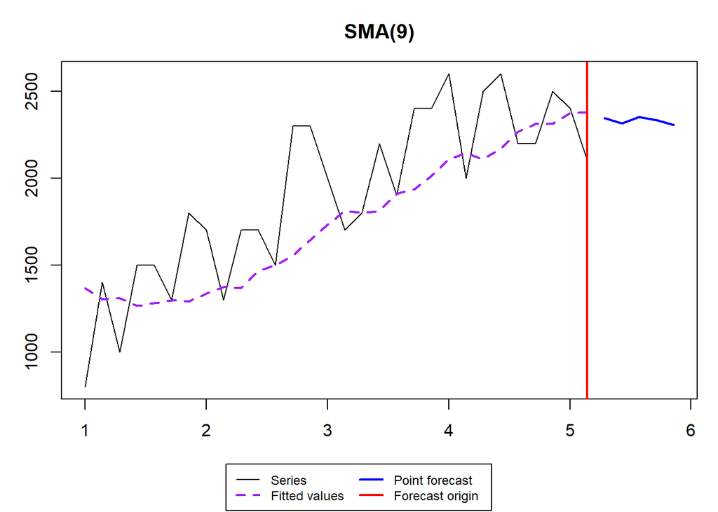

```r
# -------- PRONÓSTICOS ---------

#datos_forecast_MA9 <- forecast(modeloMA9_2, h=5) #aquí debes poner el mejor modelo
#datos_forecast_MA9
#plot(datos_forecast_MA9)


datos_fc_MA9 <- sma(datos_ts,order=9,h=5,silent=FALSE)
```

```r
fc2 <- forecast(datos_fc_MA9)
print(fc2)
```

```
## Time Series:
## Start = c(5, 3)
## End = c(6, 5)
## Frequency = 7
##          Point forecast Lower bound (2.5%) Upper bound (97.5%)
## 5.285714       2344.444           1629.815            3059.074
## 5.428571       2316.049           1597.022            3035.076
## 5.571429       2351.166           1626.746            3075.585
## 5.714286       2334.629           1603.607            3065.651
## 5.857143       2305.143           1566.051            3044.235
## 6.000000       2316.826           1567.891            3065.761
## 6.142857       2329.806           1568.895            3090.718
## 6.285714       2310.896           1535.455            3086.337
## 6.428571       2300.996           1507.983            3094.009
## 6.571429       2323.328           1509.145            3137.512
```

## 0.2 Explica el comportamiento de los resultados obtenidos.

Inicialmente se hace un suavizamiento de los datos para poder pasar a la predicción solicitada Donde order equivale a las semanas tomadas en cuenta para hacer la predicción (en este caso 3 o 9) y h equivale a los periodos que se van a predecir (que serían 5).

Posteriormente, pasamos a la parte de predicción de los datos y, debido a los valores de suavizamiento usados, se puede apreciar que la gráfica de orden 3 describe mucho mejor a los datos y en la de orden 9 se generaliza el comportamiento de estos.

## 0.3 ¿Cuál de los pronósticos obtenidos consideras más adecuado? ¿Por qué?

Por las razones previamente explicadas, creemos que el pronóstico más adecuado es el 3 debido a que los valores obtenidos se ajustan mejor a los datos reales.

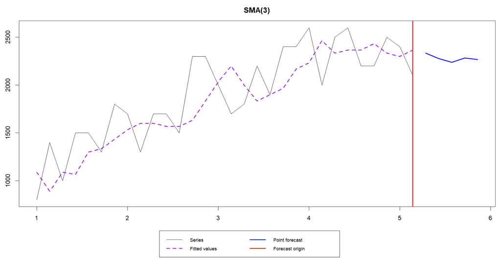